# Module 03 hw

## Question 2

Load global variables and csv files. tripdata_df is a data frame with 20 columns and 398644 rows. There are some columns that have approximately 80000 NA’s. The column ehail_fee did not import correctly, every row in this column is NA.

```r
library(dplyr)
library(tidyverse)
```

```r
library(ggplot2)

tripdata_df <- read_csv("2020_Green_Taxi_Trip_Data.csv", na = "NA")
tripdata_df
```

| VendorID | lpep_pickup_datetime | lpep_dropoff_datetime | store_and_fwd_flag | RatecodeID | PULocationID | DOLocationID | passenger_count | trip_distance | fare_amount | extra | mta_tax | tip_amount | tolls_amount | ehail_fee | improvement_surcharge | total_amount | payment_type | trip_type | congestion_surcharge |
| --- | --- | --- | --- | --- | --- | --- | --- | --- | --- | --- | --- | --- | --- | --- | --- | --- | --- | --- | --- |
| NA | 02/01/2020 12:00:00 AM | 02/01/2020 12:13:00 AM |  | NA | 108 | 55 | NA | 3.06 | 17.69 | 2.75 | 0.0 | 0.00 | 0.00 | NA | 0.3 | 20.74 | NA | NA | NA |
| 2 | 02/01/2020 12:00:09 AM | 02/01/2020 12:04:09 AM | N | 1 | 65 | 97 | 1 | 0.94 | 5.00 | 0.50 | 0.5 | 0.00 | 0.00 | NA | 0.3 | 6.30 | 2 | 1 | 0.00 |
| 2 | 02/01/2020 12:00:15 AM | 02/01/2020 12:11:39 AM | N | 1 | 168 | 167 | 1 | 2.68 | 10.50 | 0.50 | 0.5 | 0.00 | 0.00 | NA | 0.3 | 11.80 | 2 | 1 | 0.00 |
| 2 | 02/01/2020 12:00:19 AM | 02/01/2020 12:24:28 AM | N | 1 | 255 | 49 | 1 | 4.83 | 18.50 | 0.50 | 0.5 | 0.00 | 0.00 | NA | 0.3 | 19.80 | 2 | 1 | 0.00 |
| 2 | 02/01/2020 12:00:23 AM | 02/01/2020 12:05:55 AM | N | 1 | 41 | 41 | 1 | 0.85 | 5.50 | 0.50 | 0.5 | 1.36 | 0.00 | NA | 0.3 | 8.16 | 1 | 1 | 0.00 |
| 2 | 02/01/2020 12:00:26 AM | 02/01/2020 12:11:27 AM | N | 1 | 95 | 121 | 1 | 2.58 | 10.50 | 0.50 | 0.5 | 0.00 | 0.00 | NA | 0.3 | 11.80 | 1 | 1 | 0.00 |
| 2 | 02/01/2020 12:00:29 AM | 02/01/2020 12:13:38 AM | N | 1 | 43 | 244 | 2 | 4.89 | 16.50 | 0.50 | 0.5 | 0.00 | 0.00 | NA | 0.3 | 17.80 | 1 | 1 | 0.00 |
| 2 | 02/01/2020 12:00:48 AM | 02/01/2020 12:11:19 AM | N | 1 | 75 | 168 | 1 | 2.70 | 10.50 | 0.50 | 0.5 | 0.00 | 0.00 | NA | 0.3 | 11.80 | 2 | 1 | 0.00 |
| 2 | 02/01/2020 12:00:48 AM | 02/01/2020 12:03:18 AM | N | 1 | 7 | 7 | 1 | 0.32 | 3.50 | 0.50 | 0.5 | 5.00 | 0.00 | NA | 0.3 | 9.80 | 1 | 1 | 0.00 |
| 2 | 02/01/2020 12:00:50 AM | 02/01/2020 12:04:41 AM | N | 1 | 130 | 215 | 1 | 1.35 | 6.00 | 0.50 | 0.5 | 1.46 | 0.00 | NA | 0.3 | 8.76 | 1 | 1 | 0.00 |

[output cut: 9990 more lines]

```r
dim(tripdata_df)
```

```
## [1] 398644     20
```

```r
summary(tripdata_df)
```

```
##     VendorID     lpep_pickup_datetime lpep_dropoff_datetime store_and_fwd_flag
##  Min.   :1.00    Length:398644        Length:398644         Length:398644
##  1st Qu.:2.00    Class :character     Class :character      Class :character
##  Median :2.00    Mode  :character     Mode  :character      Mode  :character
##  Mean   :1.83
##  3rd Qu.:2.00
##  Max.   :2.00
##  NA's   :80893
##    RatecodeID     PULocationID    DOLocationID   passenger_count
##  Min.   : 1.0    Min.   :  1.0   Min.   :  1.0   Min.   :0.00
##  1st Qu.: 1.0    1st Qu.: 52.0   1st Qu.: 65.0   1st Qu.:1.00
##  Median : 1.0    Median : 82.0   Median :129.0   Median :1.00
##  Mean   : 1.1    Mean   :107.9   Mean   :129.4   Mean   :1.31
##  3rd Qu.: 1.0    3rd Qu.:166.0   3rd Qu.:193.0   3rd Qu.:1.00
##  Max.   :99.0    Max.   :265.0   Max.   :265.0   Max.   :8.00
##  NA's   :80893                                   NA's   :80893
##  trip_distance        fare_amount          extra            mta_tax
##  Min.   :     0.00   Min.   :-150.00   Min.   :-4.5000   Min.   :-0.5000
##  1st Qu.:     1.04   1st Qu.:   7.00   1st Qu.: 0.0000   1st Qu.: 0.5000
##  Median :     1.97   Median :  11.00   Median : 0.5000   Median : 0.5000
##  Mean   :     4.91   Mean   :  15.32   Mean   : 0.8915   Mean   : 0.4012
##  3rd Qu.:     4.08   3rd Qu.:  20.06   3rd Qu.: 1.0000   3rd Qu.: 0.5000
##  Max.   :159907.16   Max.   : 458.00   Max.   :16.7400   Max.   : 3.5500
##
##    tip_amount        tolls_amount     ehail_fee      improvement_surcharge
##  Min.   :-10.5600   Min.   : 0.0000   Mode:logical   Min.   :-0.3000
##  1st Qu.:  0.0000   1st Qu.: 0.0000   NA's:398644    1st Qu.: 0.3000
##  Median :  0.0000   Median : 0.0000                  Median : 0.3000
##  Mean   :  0.9865   Mean   : 0.2823                  Mean   : 0.2918
##  3rd Qu.:  1.6600   3rd Qu.: 0.0000                  3rd Qu.: 0.3000
##  Max.   :641.2000   Max.   :33.6200                  Max.   : 0.3000
##
##   total_amount      payment_type     trip_type     congestion_surcharge
##  Min.   :-150.30   Min.   :1.00    Min.   :1.00    Min.   :0.00
##  1st Qu.:   8.80   1st Qu.:1.00    1st Qu.:1.00    1st Qu.:0.00
##  Median :  14.12   Median :1.00    Median :1.00    Median :0.00
##  Mean   :  18.50   Mean   :1.45    Mean   :1.02    Mean   :0.47
##  3rd Qu.:  24.30   3rd Qu.:2.00    3rd Qu.:1.00    3rd Qu.:0.00
##  Max.   : 651.50   Max.   :5.00    Max.   :2.00    Max.   :2.75
##                    NA's   :80893   NA's   :80894   NA's   :80893
```

## Question 3

For this question I decided that it would be best to find outliers in the data in order to find values that did not match my expectations. The three columns I picked were passenger_count fare_amount and trip_distance because these columns are all of type dbl and do not require further parsing in order to analyze. For this analysis an outlier is defined as being more than 2 standard deviations away.

```r
# passenger_count
passenger_sd <- sd(tripdata_df$passenger_count, na.rm = TRUE)
passenger_mean <- mean(tripdata_df$passenger_count, na.rm = TRUE)
tripdata_df$passenger_z <- abs((passenger_mean-tripdata_df$passenger_count)/passenger_sd)
passenger_outliers <- which(tripdata_df$passenger_z > 2)
length(passenger_outliers)
```

```
## [1] 15778
```

```r
# fare_amount
fare_sd <- sd(tripdata_df$fare_amount, na.rm = TRUE)
fare_mean <- mean(tripdata_df$fare_amount, na.rm = TRUE)
tripdata_df$fare_amount_z <- abs((fare_mean - tripdata_df$fare_amount)/fare_sd)
fare_outliers <- which(tripdata_df$fare_amount_z > 2)
length(fare_outliers)
```

```
## [1] 20645
```

```r
# trip_distance
trip_sd <- sd(tripdata_df$trip_distance, na.rm = TRUE)
trip_mean <- mean(tripdata_df$trip_distance, na.rm = TRUE)
tripdata_df$trip_distance_z <- abs((trip_mean - tripdata_df$trip_distance)/trip_sd)
trip_outliers <- which(tripdata_df$trip_distance_z > 2)
length(trip_outliers)
```

```
## [1] 15
```

I found that there were 15778 outliers for passenger_count, 20645 for fare_amount, and only 15 for trip_distance. The outliers for trip_distance are interesting because there are so few which makes sense since most taxis don’t travel long distance. I decided to investigate further.

```r
#trip distance only
tripdata_df %>%
  select(trip_distance,trip_distance_z) %>%
  filter(trip_distance_z > 2)
```

| trip_distance | trip_distance_z |
| --- | --- |
| 20444.29 | 52.99164 |
| 6264.50 | 16.22877 |
| 122181.83 | 316.75887 |
| 34695.14 | 89.93874 |
| 5388.10 | 13.95659 |
| 8476.68 | 21.96412 |
| 37266.59 | 96.60554 |
| 29890.02 | 77.48087 |
| 4566.44 | 11.82634 |
| 159907.16 | 414.56649 |

[output cut: 5 more lines]

```r
#With fare_amount
tripdata_df %>%
  select(fare_amount,trip_distance,trip_distance_z,fare_amount_z) %>%
  filter(trip_distance_z > 2)
```

| fare_amount | trip_distance | trip_distance_z | fare_amount_z |
| --- | --- | --- | --- |
| 35.42 | 20444.29 | 52.99164 | 1.6203389 |
| 29.06 | 6264.50 | 16.22877 | 1.1077495 |
| 25.79 | 122181.83 | 316.75887 | 0.8442011 |
| 30.01 | 34695.14 | 89.93874 | 1.1843155 |
| 36.17 | 5388.10 | 13.95659 | 1.6807858 |
| 29.26 | 8476.68 | 21.96412 | 1.1238687 |
| 16.73 | 37266.59 | 96.60554 | 0.1140030 |
| 13.04 | 29890.02 | 77.48087 | 0.1833956 |
| 0.00 | 4566.44 | 11.82634 | 1.2343652 |
| 33.83 | 159907.16 | 414.56649 | 1.4921916 |

[output cut: 5 more lines]

These results lead me to believe that some sort of mistake happened during data entry because I do not believe these values are real. It is not believable that someone rode a taxi for 20,000 miles. Furthermore, these values were filtered by z > 2 but the smallest z score here is 11.8. I decided to also look at the fare paid for these trips and they are normal which reinforces the theory that these people traveled a normal distance but it was recorded incorrectly.

## Question 4

This histogram visualizes my previous work and shows that the data is skewed due to the extremely large outliers.

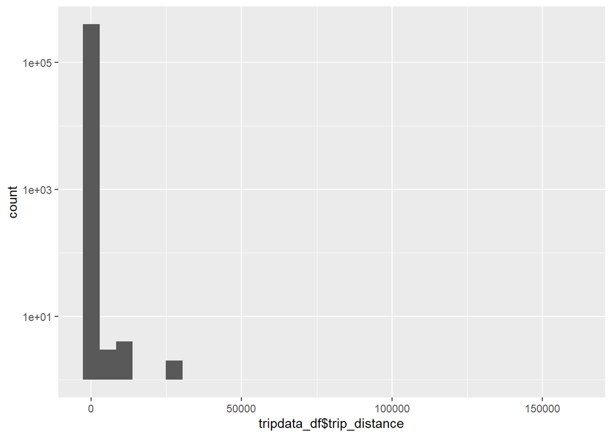

```r
ggplot(tripdata_df) + geom_histogram(mapping = aes(x = tripdata_df$trip_distance)) + scale_y_log10()
```

## Question 5

Using the length() function we can se that there aare 3750 outliers in the tip_amount column and 15 outliers in the trip_distance column. The dataframe tripdata_df was updated to remove the tip_amount outliers by piping in the original dataframe into the function filter(tip_z < 3)

```r
#tip_amount
tip_sd <- sd(tripdata_df$tip_amount, na.rm = TRUE)
tip_mean <- mean(tripdata_df$tip_amount, na.rm = TRUE)
tripdata_df$tip_z <- abs((tip_mean-tripdata_df$tip_amount)/tip_sd)
tip_outliers <- which(tripdata_df$tip_z > 3)

#See question 3 for trip_distance outlier code

#tip_amount
tripdata_df %>%
  select(tip_amount,tip_z) %>%
  filter(tip_z > 3)
```

| tip_amount | tip_z |
| --- | --- |
| 11.05 | 4.556663 |
| 9.00 | 3.628445 |
| 10.00 | 4.081234 |
| 9.01 | 3.632973 |
| 9.65 | 3.922758 |
| 7.71 | 3.044347 |
| 10.00 | 4.081234 |
| 13.00 | 5.439601 |
| 9.08 | 3.664668 |
| 9.10 | 3.673724 |

[output cut: 3740 more lines]

```r
#trip_distance
tripdata_df %>%
  select(trip_distance,trip_distance_z) %>%
  filter(trip_distance_z > 3)
```

| trip_distance | trip_distance_z |
| --- | --- |
| 20444.29 | 52.99164 |
| 6264.50 | 16.22877 |
| 122181.83 | 316.75887 |
| 34695.14 | 89.93874 |
| 5388.10 | 13.95659 |
| 8476.68 | 21.96412 |
| 37266.59 | 96.60554 |
| 29890.02 | 77.48087 |
| 4566.44 | 11.82634 |
| 159907.16 | 414.56649 |

[output cut: 5 more lines]

```r
#Remove tip_amount outliers
tripdata_df <- tripdata_df %>%
  filter(tip_z < 3)
```

## Question 6

tripdata_df2 was created to remove trip_distance outliers and was used in ggplot().

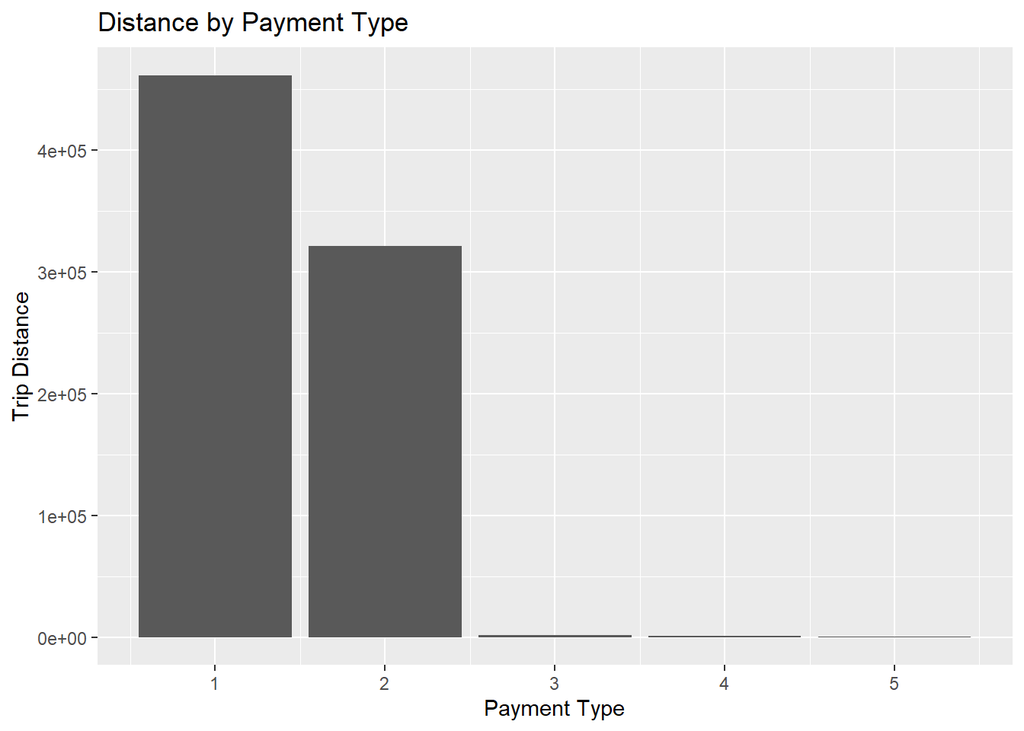

```r
#Filter outliers
tripdata_df2 <- tripdata_df %>%
  filter(trip_distance_z < 3)

ggplot(tripdata_df2, aes(x=tripdata_df2$payment_type, y=tripdata_df2$trip_distance)) + geom_bar(stat = "identity") + labs(title = "Distance by Payment Type") + labs(x="Payment Type", y="Trip Distance")
```